# Praca domowa 5

Ilona Bednarz, Anna Kozak

20.11.2018

## Zadanie

Zadanie polegało na przeprowadzeniu eksperymentu badającego umiejętność czytania wykresów przez odbiorców. Eksperyment miał sprawdzić, w jakim stopniu jest możliwe manipulowanie przekazem prezentowanym na wykresie, bez przekłamywania liczb, a jedynie za pomocą doboru techniki wizualizacji, kolorystyki i innych parametrów graficznych.

## Eksperyment

### Eksperyment 1

Utworzony został wykres prezentujący (fikcyjne) dane liczbowe, opatrzony tytułem oraz opisem osi. Był to wykres kołowy, który miał wprowadzić czytelnika w błąd poprzez zastosowanie trzeciego wymiaru. Ponadto kolory wycinków koła zostały tak dobrane, aby małe wartości wydawały się większe i na odwrót.

Poniżej wykres.

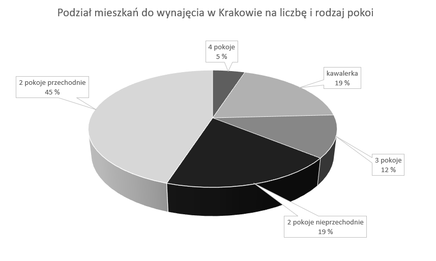

### Eksperyment 2

Wykres został utworzony z przeskalowanych danych z poprzedniego eksperymnentu. Był to wykres słupkowy, wykonany wzorcowo, bez żadnych manipulacji odbiorcą.

Poniżej wykres.

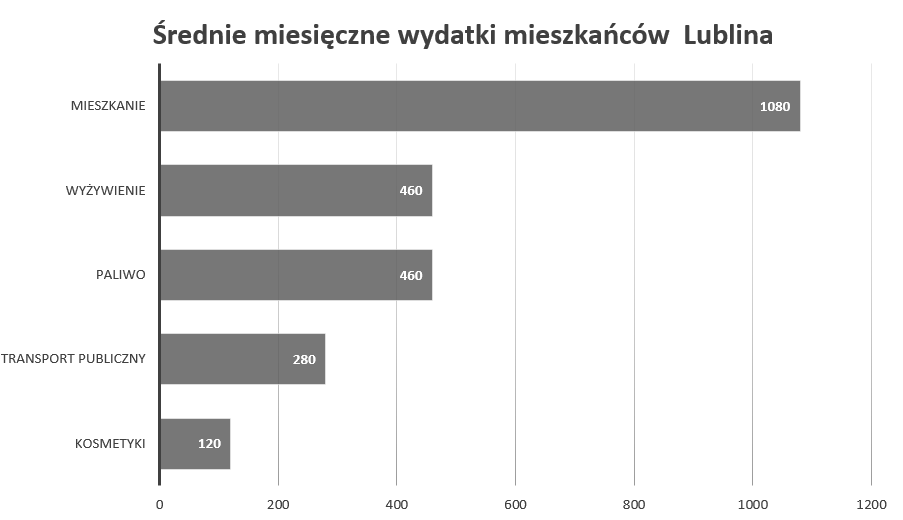

## Ankieta

Przeprowadziłyśmy ankietę ([link](https://docs.google.com/forms/d/e/1FAIpQLSeu8o2Oe8g54ihPOxDwHKtDMIst1O3ULmSlPP2CWIPAnQ4fhg/viewform?fbclid=IwAR0X7FFPgbNr0ASfYv4H3O9vC5eKMEoq2BnmrKz9d-6xcDyyV6pNJpytFD0)) na próbie 94 osób zawierającą powyższe wykresy. Po obejrzeniu każdego z wykresów ankietowani mieli za zadanie odpowiedzieć na trzy proste pytania, które sprawdzały, czy dobrze odczytali wykres. Po każdym wykresie pytania były takie same (analogiczne), aby możliwe było porównanie odpowiedzi.

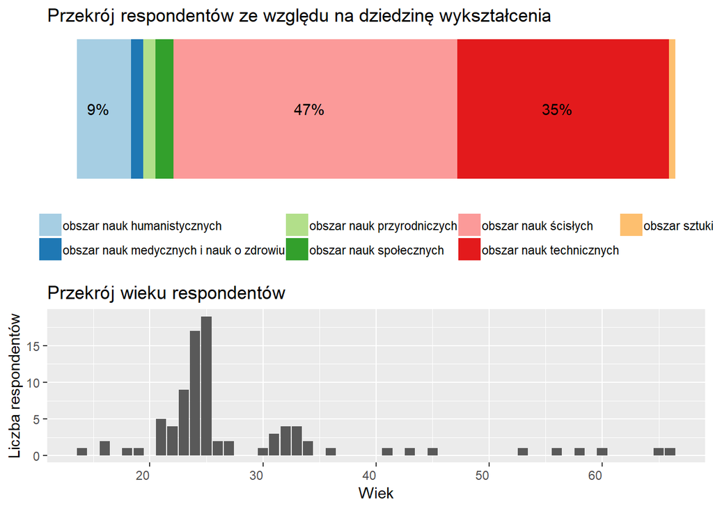

## Wyniki ankiety

Poniżej prezentujemy wyniki uzyskane w ankiecie.

### Pytanie pierwsze: jakiego miasta dotyczyły dane?

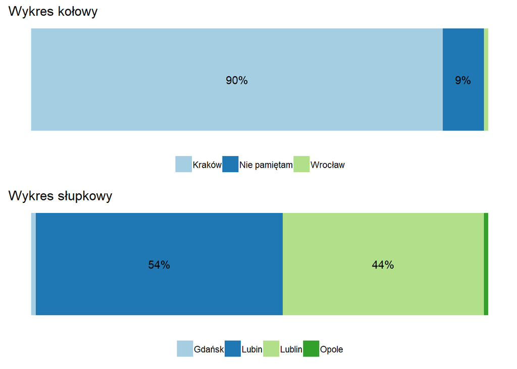

Pierwszym pytaniem jakie zostało zadane naszym ankietowanym dotyczyło miasta z jakiego pochodziły dane zamieszczone na wykresie. W pierwszym przypadku było to miasto Kraków, jak widzimy 90% odpowiedziało dobrze. Nastomiast w pytaniu do wykresu słupkowego zawarłyśmy pułakpę. Poprawną odpowiedzią było miasto Lublin, większość odpowiedziała Lubin, co oznacza, że ankietowani zwracają uwagę na tytuł, ale nie do końca uważnie go czytają.

### Pytanie 2: Porównanie dwóch wartości.

Przy wykresie kołowym pytałyśmy, czy liczba mieszkań z 2 pokojami nieprzechodnimi jest większa od liczby mieszkań z 3 pokojami. Natomiast przy wykresie słupkowym pytałyśmy, czy wydatki na wyżywienie były większe niż na transport publiczny.

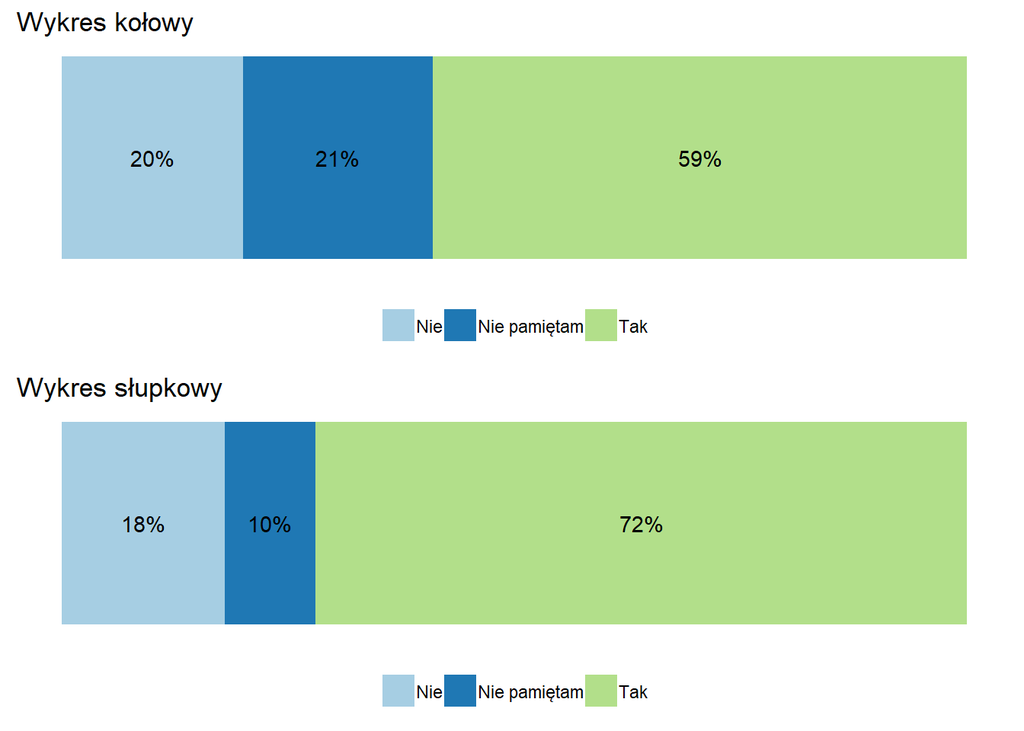

W obu pytaniach poprawna odpowiedzą jest “Tak”. Zarówno w pytaniu do wykresu kołowego, jak i do wykresu słupkowego, wiekszość odpowiedziała poprawnie.

### Pytanie 3: Czy którekolwiek dwie grupy były równoliczne?

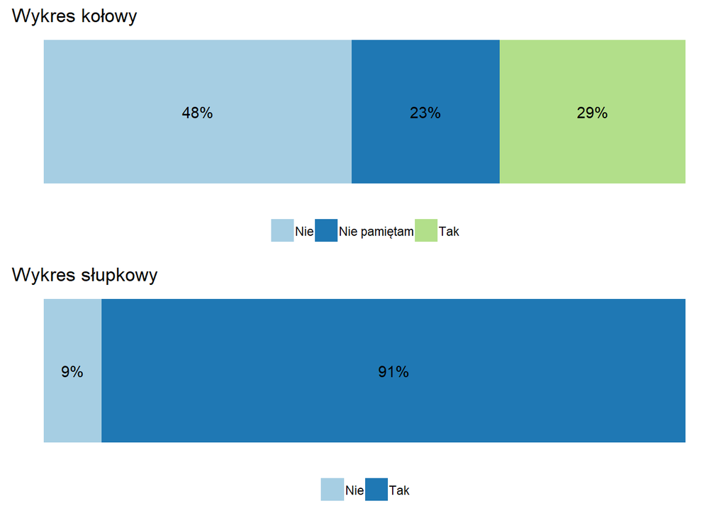

Na koniec zapytałyśmy ankietowanych, czy są jakiekolwiek dwie grupy równoliczne. Odpowiedzią poprawną było “Tak”. W przypadku wykresu słupkowego 91% ankietowanych odpowiedziało poprawnie. Analizując wyniki odpowiedzi z wykresu kołowego widzimy, że prawie połowa dała odpowiedź “Nie”“, a 23% nie pamiętało. Niecałe 30% odpowiedziało poprawnie. Możemy wnioskować, że odczytywanie z wykresu kołowego jest dla odbiorców trudniejsze, przez co są podatni na manipulację.

Podsumowując nasze eksperymenty i wyniki ankiety widzimy, że wykres kołowy nie jest najlepszym narzędziem do prezentacji wyników. Zwykły wykres słupowy jest zdecydowanie lepszym narzędziem.